# Lecture 3: ANCOVA and multiple regression with deer antlers

## 3. Can we compare raw slopes?

A model predicts plant growth from annual rainfall (mm) and soil nitrogen (mg/kg). The predictors have very different units and ranges.

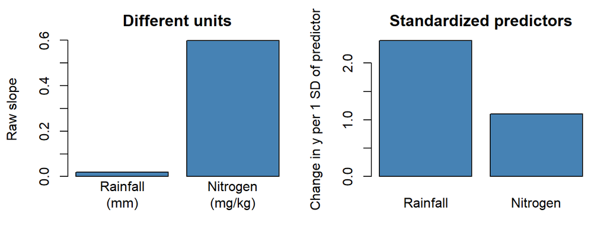

**a.** Is the predictor with the numerically larger raw slope necessarily the biologically stronger predictor? Select one: [ ] Yes [X] No.

**b.** Why does predictor scale affect the numerical value of a regression slope?

**Correct answer:** A slope is measured in response units per predictor unit. Changing the predictor’s units changes the numerical slope, even though the relationship represented by the model is unchanged.

**Answer:**  
The response remains in the same units, but a slope is measured as change in growth per unit of a predictor. Changing a predictor’s units changes the numerical slope, so raw slopes for predictors on different scales are not directly comparable.

**My comment:** The original answer confused the predictor units. The slope’s units are response units per predictor unit, and changing the predictor’s scale changes the numerical slope.

The worksheet gives the standardization formula:

$$z = \frac{x - \bar{x}}{SD(x)}$$

**c.** After z-standardizing predictors, what does a slope represent?

**Correct answer:** The expected change in the response for a one-standard-deviation increase in that predictor, holding other predictors constant.

**Answer:**  
The expected change in the response for a one-standard-deviation increase in that predictor, holding the other predictors constant.

**My comment:** A standardized predictor’s slope is in response units per one standard deviation of the predictor; it is not a ratio of the proportion of the data.

**d.** Does standardizing the predictors change the model’s fitted values or $R^2$? What does it change?

**Correct answer:** No. Standardizing predictors leaves fitted values and $R^2$ unchanged, but expresses slopes per one-standard-deviation change in the predictors.

**Answer:**  
Standardizing predictors does not change the fitted values or $R^2$. It changes the coefficient scale, so slopes are expressed per one-standard-deviation change in the predictor.

**My comment:** Standardization rescales the predictor coefficients; it does not change the response values or the model’s fit when the same model is otherwise used.

## 4. When predictors tell us almost the same thing

Leaf length and plant height are strongly correlated, and both are included as predictors of herbivore damage.

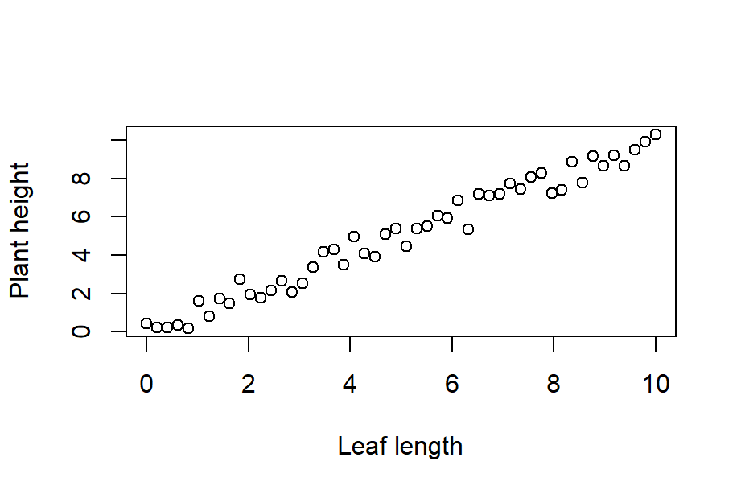

**a.** What makes it difficult to estimate their independent effects?

**Correct answer:** Because leaf length and plant height are strongly correlated, it is difficult to separate their individual associations with herbivore damage.

**Answer:**  
They are strongly correlated, so it is difficult to distinguish their separate associations with herbivore damage.

**My comment:** The issue is their strong correlation (multicollinearity), which makes their independent effects hard to separate; the anatomical link alone does not explain the statistical problem.

**b.** Would strong multicollinearity necessarily prevent the model from predicting herbivore damage well? Explain.

**Correct answer:** No. Multicollinearity can make individual coefficients imprecise and hard to interpret, while predictions may still be good. Correlated variables should only be combined into an index if it is biologically meaningful.

**Answer:**  
Not necessarily. Strong multicollinearity can make individual coefficients imprecise or difficult to interpret, while the model may still predict well. If biologically justified, correlated measurements can sometimes be combined into a meaningful index.

**My comment:** A length-to-width ratio is not supported by the question’s variables (leaf length and plant height). Only combine predictors into an index when that index has a clear biological rationale.

**c.** Which aspect is especially threatened by multicollinearity: prediction of $y$, or precise interpretation of individual coefficients?

**Answer:** Precise interpretation of individual coefficients.

## 5. More predictors are not always better

Two models predict breeding success. Model A uses 3 biologically motivated predictors. Model B uses 18 available environmental variables and explains more variance in the original dataset.

**a.** Is Model B automatically the better model? Select one: [ ] Yes [X] No.

**b.** What is overfitting in your own words?

**Correct answer:** Overfitting is when a model captures patterns specific to its training data, including noise, and therefore performs poorly on new data.

**Answer:**  
Overfitting occurs when a model captures patterns specific to its training data, including noise, and therefore performs poorly on new data.

**My comment:** The original wording suggested that a model stops representing reality altogether. More specifically, overfitting means it models training-specific noise or patterns that do not generalize.

**c.** How could a model explain the training data very well but perform poorly on new data?

**Correct answer:** It may have overfit the training data by learning noise or accidental patterns that do not generalize to new data.

**Answer:** If the model is overfit, it may capture noise or accidental patterns in the training data that do not generalize to new data.

**My comment:** This explains the mechanism: performance on new data is poor when the model learns training-specific noise rather than general patterns.

**d.** Why can starting from a biological hypothesis be preferable to retaining variables simply because they have small P-values?

**Correct answer:** A biological hypothesis gives a principled reason to include predictors and helps keep the analysis focused. Selecting variables only by small p-values can capture chance associations, especially when many variables are tested; a biological rationale does not, by itself, prove causation.

**Answer:** A biological hypothesis gives a reason to include predictors and helps keep the analysis focused. Selecting variables only because they have small p-values can retain coincidental associations with little biological meaning. Testing many variables also increases the chance of finding a small p-value by chance, a problem associated with p-hacking.

**My comment:** A biological rationale supports interpreting an association, but it does not by itself establish causation.

## 6. ANCOVA combines groups and continuous predictors

An experiment measures growth across a nutrient gradient in two light treatments. Consider the three schematic outcomes:

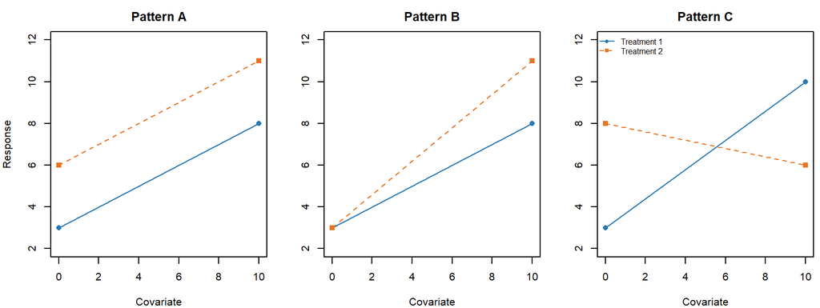

**a.** Which pattern shows different intercepts but the same slope? **Answer:** A.

**b.** Which pattern shows different slopes between treatments? **Answer:** B and C.

**c.** Which pattern shows a crossover interaction? **Answer:** C.

**d.** In an ANCOVA, what does a treatment $\times$ nutrient interaction mean biologically?

**Correct answer:** The effect of nutrient level on growth depends on the light treatment; equivalently, the treatment difference changes across the nutrient gradient.

**Answer:**  
The effect of nutrient level on growth depends on the light treatment (equivalently, the treatment difference changes across the nutrient gradient).

**My comment:** An interaction means the effect of one predictor changes across levels of the other; it does not merely mean that both factors affect the response.

## 7. Read ANCOVA coefficients as lines

$$y = \beta_0 + \beta_x x + \beta_T T + \beta_{xT}(x \times T)$$

Let $T = 0$ for Control and $T = 1$ for Treatment. Suppose $\beta_0 = 4$, $\beta_x = 0.5$, $\beta_T = 2$, and $\beta_{xT} = 0.3$.

**a.** What is the intercept for Control? **Answer:** 4. What is its slope? **Answer:** 0.5.

**b.** What is the intercept for Treatment? **Answer:** 6. What is its slope? **Answer:** 0.8.

**c.** Which coefficient tells us that the slopes differ? **Answer:** $\beta_{xT}$.

**d.** At $x = 0$, what is the expected difference between treatments? **Answer:** 2 (Treatment minus Control; the reverse contrast is $-2$).

**e.** Does the treatment difference remain constant as $x$ increases? Explain.

**Correct answer:** No. Because the slopes differ by $\beta_{xT} = 0.3$, the treatment difference changes as $x$ increases.

**Answer:**  
No. Because the slopes differ by $\beta_{xT} = 0.3$, the treatment difference changes as $x$ increases.

## 8. Turn a multiple model back into biology

A standardized multiple regression of bird fledging success on food availability and nest concealment gives $\hat{\beta}_{food} = 2.4$ offspring per SD and $\hat{\beta}_{concealment} = 0.6$ offspring per SD, with both predictors in the same model.

**a.** Interpret $\hat{\beta}_{food}$ in one biological sentence.

**Correct answer:** Holding nest concealment constant, a one-standard-deviation increase in food availability is associated with an expected increase of 2.4 offspring in fledging success.

**Answer:**  
Holding nest concealment constant, a one-standard-deviation increase in food availability is associated with an expected increase of 2.4 offspring in fledging success.

**My comment:** The predictors are standardized, but the response is measured in offspring. Therefore, the coefficient is not a 2.4% increase.

**b.** What does comparing 2.4 with 0.6 suggest, and what caution should remain if the predictors are strongly correlated?

**Correct answer:** The standardized food coefficient is four times the concealment coefficient in this model. Strong correlation between predictors can make their individual coefficients unstable and difficult to interpret, so this does not necessarily imply a fourfold causal effect.

**Answer:**  
The standardized food coefficient is four times the standardized concealment coefficient in this model. If the predictors are strongly correlated, their individual coefficients may be unstable and difficult to interpret; this comparison does not necessarily mean that food has four times the causal effect.

**My comment:** Correlation between predictors does not automatically make the prediction wrong. It mainly makes the separate coefficient estimates less stable and their interpretation more difficult.

## Exit ticket

Complete the sentence: The phrase **“holding the other predictors constant”** matters because…

**Answer:**  
It matters because each coefficient describes the association between its predictor and the response after accounting for the other predictors in the model.